# ANOVA Repeated Measures

Mark Christopher Adkins

Created: 2020-09-11 Last Modified: 2023-07-29

# ANOVA - Repeated Measures

## Load Libraries

```r
library(rstatix)  # pairwise_t_test()
library(psych)    # describeBy()
library(ez)       # ezANOVA()
library(here)
library(tidyverse)
```

If you have trouble installing the tidyverse package, you can install/load the individual packages that we need.

```r
library(dplyr)   # mutate()
library(tidyr)   # pivot_longer()
library(ggplot2) # plotting
library(readr)   # importing csv
```

## Create/Import Data

The next step is to either load some data into R or create some data ourselves. For the exercises within this lab, we will load some data from the file “stepspday.csv”[^1] (which should be inside the “data” folder within your R project).

```r
# import data and force the read_csv() function to make
# the variables into certain types
data_ANOVA_rm <- read_csv(file = here("data",
                            "stepspday.csv"))
```

## Clean Up the Data

For data imported using the {readr} package, you can check whether there were any parsing problems using the `problems()` function.

```r
# check for parsing problems
# e.g., were there problems forcing a variable to be a certain type
problems(data_ANOVA_rm)
```

```
## # A tibble: 0 x 5
## # ... with 5 variables: row <int>, col <int>, expected <chr>, actual <chr>,
## #   file <chr>
```

It is always a good idea to `View()` your data **every** time you import it to ensure that the data look the way expect. This is especially important if you have never seen the data before.

```r
# take a peak at the data
View(data_ANOVA_rm)
```

| ID | Week1 | Week6 | Week12 |
| --- | --- | --- | --- |
| A | 6 | 8 | 10 |
| B | 4 | 5 | 6 |
| C | 5 | 5 | 5 |
| D | 1 | 2 | 3 |
| E | 3 | 1 | 2 |
| F | 2 | 3 | 4 |

Once we look at our data, we should notice that it is in *wide* format, but many functions in R need data to be in *long* format (most notably ggplot2 functions and many functions for repeated measures ANOVA).

The following animation show the process we need to do to convert data from *wide* format to *long* format using the `pivot_longer()` function from the *tidyr* package.

Here is a helpful animation by Alison Hill [^2] showing how the `pivot_longer()` function works.

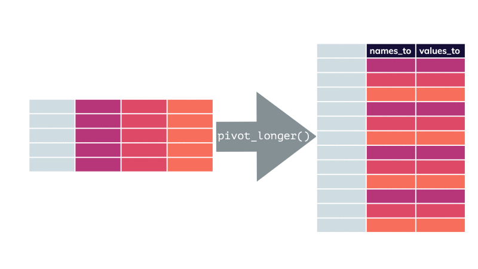

To use `pivot_longer()`, we need at least four arguments:

- *data*
  - a data.frame or tibble
- *cols*
  - the columns which you want to gather together
- *names_to*
  - the name of a new vector which holds the names of the columns from which a value came from
- *values_to*
  - the name of a new vector which holds the values from the columns we are converting into a long column

Let’s try it out!

```r
# convert data into long format for the Weeks
data_ANOVA_rm_long <- data_ANOVA_rm %>%
  pivot_longer(cols = c(Week1, Week6, Week12),
               names_to = "Week",
               values_to = "ave_steps_per_day")
```

```r
# take a peak at the data
View(data_ANOVA_rm_long)
```

| ID | Week | ave_steps_per_day |
| --- | --- | --- |
| A | Week1 | 6 |
| A | Week6 | 8 |
| A | Week12 | 10 |
| B | Week1 | 4 |
| B | Week6 | 5 |
| B | Week12 | 6 |
| C | Week1 | 5 |
| C | Week6 | 5 |
| C | Week12 | 5 |
| D | Week1 | 1 |

[output cut: 8 more lines]

### Puzzle

Instead of manually writing out the names of the variables you want to `pivot_longer()`, try using the tidy helper function `starts_with()` to select the variables. You can also remove the prefixes from the variables using the “names_prefix” argument in the `pivot_longer()` function.

```r
data_ANOVA_rm %>%
  pivot_longer(cols = <YOUR CODE HERE>,
               names_to = "Week",
               values_to = "ave_steps_per_day",
               names_prefix = "Week")
```

### Show Solution

```r
# convert the data to long format
data_ANOVA_rm %>%
  pivot_longer(cols = starts_with("Week"),
               names_to = "Week",
               values_to = "ave_steps_per_day",
               names_prefix = "Week")
```

```
## # A tibble: 18 x 3
##    ID    Week  ave_steps_per_day
##    <chr> <chr>             <dbl>
##  1 A     1                     6
##  2 A     6                     8
##  3 A     12                   10
##  4 B     1                     4
##  5 B     6                     5
##  6 B     12                    6
##  7 C     1                     5
##  8 C     6                     5
##  9 C     12                    5
## 10 D     1                     1
## 11 D     6                     2
## 12 D     12                    3
## 13 E     1                     3
## 14 E     6                     1
## 15 E     12                    2
## 16 F     1                     2
## 17 F     6                     3
## 18 F     12                    4
```

```r
data_ANOVA_rm_long <- data_ANOVA_rm_long %>%
  mutate(ID = parse_factor(ID),
         Week = parse_factor(Week))
```

## Check Assumptions

### Normality in **Each** Group

#### QQ-Plots

A quantile-quantile (qq-plot) is one way to visually assess whether a variable is approximately normally distributed. If each variable were normally distributed, then the points would fall exactly on the line.

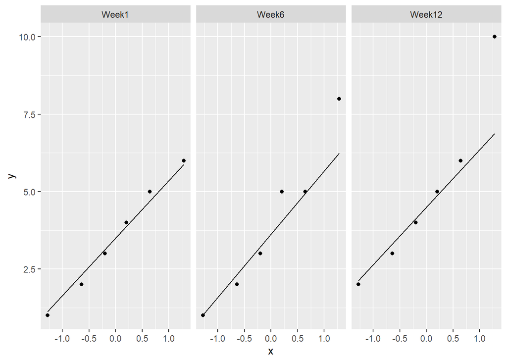

```r
# assess normality using a qqplot
# - for qqplot you need to use an aesthetic called "sample"
ggplot(data = data_ANOVA_rm_long,
       mapping = aes(sample = ave_steps_per_day)) +
    geom_qq() +
    geom_qq_line() +
    facet_grid(~Week)
```

#### Box Plots

A box plot is another way to visually assess the distribution of a variable. A few things to look for when assessing a distribution for normality:

- The median is centred within the box (the inter-quartile)
- There are no outliers
- Both whiskers extend an appropriate amount beyond the upper and lower edges of the box.

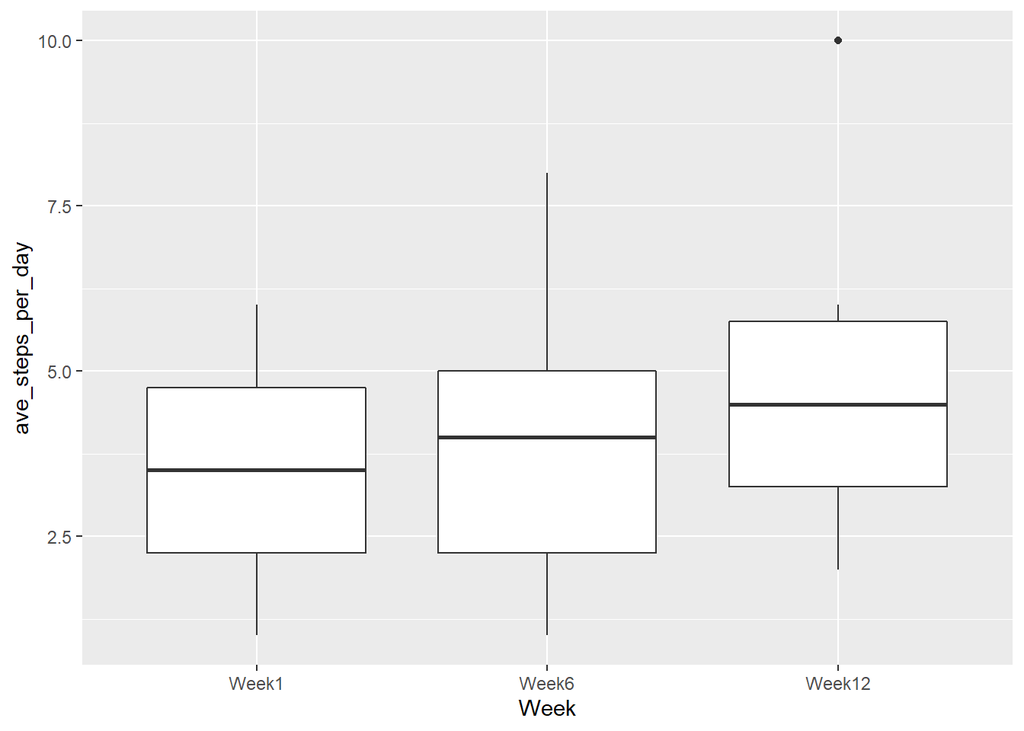

```r
# create a box plot to show "recall" distribution for each group
ggplot(data_ANOVA_rm_long,
       aes(x = Week,
           y = ave_steps_per_day)) +
    geom_boxplot()
```

#### Using Descriptive Statistics

In past exercises, we have used the `describe()` function to compute descriptive statistics. Today, we will use a related function from the {psych} package called `describeBy()` (note the capital “B”). This will break your data set into groups, and compute descriptive statistics separately for each group.

```r
# assess normality using descriptive statistics
describeBy(x = data_ANOVA_rm_long$ave_steps_per_day,
           group = data_ANOVA_rm_long$Week)
```

```
##
##  Descriptive statistics by group
## group: Week1
##    vars n mean   sd median trimmed  mad min max range skew kurtosis   se
## X1    1 6  3.5 1.87    3.5     3.5 2.22   1   6     5    0     -1.8 0.76
## ------------------------------------------------------------
## group: Week6
##    vars n mean   sd median trimmed  mad min max range skew kurtosis   se
## X1    1 6    4 2.53      4       4 2.22   1   8     7 0.31    -1.55 1.03
## ------------------------------------------------------------
## group: Week12
##    vars n mean   sd median trimmed  mad min max range skew kurtosis   se
## X1    1 6    5 2.83    4.5       5 2.22   2  10     8 0.66    -1.11 1.15
```

### Sphericity

Mauchly’s test can be used to assess for violations of sphericity. The {EZ} package conducts Mauchly’s test along with the ANOVA. See output below (in conduct test section).

## Conduct Test

- *data* - the data.frame/tibble where you data “lives”
- *wid* - a variable with a unique subject id for each subject
  - if the variable you supply to the *wid* argument is not a factor, the function will temporarily convert it for you
- *within* - a variable containing within subject grouping information
- *dv* - the outcome variable

```r
# conduct an independent samples ANOVA
# then save the results into an object
ANOVA_results <- ezANOVA(data = data_ANOVA_rm_long,
        wid = ID,
        within = Week,
        dv = ave_steps_per_day)
```

If you are unsure what some of the values in the `ezANOVA()` output are referring to, then check the help documentation in the *Value* section. You can open the help documentation using the following code.

```r
?ez::ezANOVA
```

```r
# Check the results from Levene's test
ANOVA_results$`Mauchly's Test for Sphericity`
```

```
##   Effect         W          p p<.05
## 2   Week 0.2469136 0.06096632
```

Be sure to ALWAYS always check the results of Mauchly’s test for sphericity PRIOR to checking the ANOVA results because if there was a problem with sphericity of variances then you can’t trust the *p*-value from the ANOVA.

If there is a problem with sphericity, then you will need to use a correction.

- Note the little clickable arrow pointing to the right. This button lets you view more columns from these results.

```
ANOVA_results$`Sphericity Corrections`
```

|  | Effect | GGe | p[GG] | p[GG]<.05 | HFe | p[HF] | p[HF]<.05 |
| --- | --- | --- | --- | --- | --- | --- | --- |
| 2 | Week | 0.5704225 | 0.09659902 |  | 0.6277372 | 0.08981371 |  |

```r
ANOVA_results$ANOVA
```

|  | Effect | DFn | DFd | F | p | p<.05 | ges |
| --- | --- | --- | --- | --- | --- | --- | --- |
| 2 | Week | 2 | 10 | 3.888889 | 0.05631351 |  | 0.07253886 |

## Post-Hoc Tests

In order to conduct all pairwise *paired* t-tests, we will be using the `pairwise_t_test()` function from the {rstatix} package (don’t forget to install it first!).

To use this function, we need to specify a few arguments:

- *data*
  - a data.frame or tibble
- *formula*
  - a formula which has the DV followed by ~ and the IV (grouping variable)
- *paired*
  - this needs to be set to `TRUE` so that function knows that we have paired data
- *p.adjust.method*
  - correction for multiple tests
- *detailed*
  - this returns extra information from the t-tests about confidence intervals, etc.

The nice thing about this function is that the results are returned as a data.frame/tibble. So we can use other functions that work with this type of result to remove unneeded columns. In this example, we are going to remove the column of uncorrected p-values so that we don’t accidentally use them in our results discussion.

```r
# conduct all pairwise, paired, t-tests
pairwise_t_test(data = data_ANOVA_rm_long,
                formula = ave_steps_per_day ~ Week,
                paired = TRUE,
                p.adjust.method = "bonferroni",
                detailed = TRUE) %>%
  select(-p)
```

| estimate | .y. | group1 | group2 | n1 | n2 | statistic | df | conf.low | conf.high | method | alternative | p.adj | p.adj.signif |
| --- | --- | --- | --- | --- | --- | --- | --- | --- | --- | --- | --- | --- | --- |
| -0.5 | ave_steps_per_day | Week1 | Week6 | 6 | 6 | -0.8885233 | 5 | -1.946547 | 0.9465472 | T-test | two.sided | 1.000 | ns |
| -1.5 | ave_steps_per_day | Week1 | Week12 | 6 | 6 | -2.0868250 | 5 | -3.347722 | 0.3477221 | T-test | two.sided | 0.274 | ns |
| -1.0 | ave_steps_per_day | Week6 | Week12 | 6 | 6 | -3.8729833 | 5 | -1.663721 | -0.3362786 | T-test | two.sided | 0.035 | * |

# Friedman Rank Sum Test

In the event that the assumptions of normality and sphericity were not met, we can conduct the Friedman Rank Sum test.

The formula gets a bit tricky. The only thing we need to change from this ANOVA type formula is to add `|ID` to the end. This tells the function to pair the tests using the variable *ID*.

```r
friedman.test(formula = ave_steps_per_day~Week|ID,
              data = data_ANOVA_rm_long)
```

```
##
##  Friedman rank sum test
##
## data:  ave_steps_per_day and Week and ID
## Friedman chi-squared = 5.2, df = 2, p-value = 0.07427
```

# Acknowledgements

- The lovely “DIV TIPS” were made using code from a fantastic blog entry by Desirée de leon at https://desiree.rbind.io/post/2019/making-tip-boxes-with-bookdown-and-rmarkdown/
- The copy to clipboard buttons were created using Klippy https://rlesur.github.io/klippy/reference/klippy.html

This work is licensed under a [Creative Commons Attribution-NonCommercial 4.0 International License](http://creativecommons.org/licenses/by-nc/4.0/).

[^1]: Gravetter, F. J. & Wallnau, L. B. (2016). Statistics for the behavioural sciences. (10th ed.). Belmont, CA: Wadsworth, Cengage Learning.
[^2]: pivot_longer() animation retrieved from https://raw.githubusercontent.com/apreshill/teachthat/master/pivot/pivot_longer_smaller.gif